# Bay Wheels System Dataset

## by Bindushree

## Investigation Overview

This data set includes information about individual rides made in a bike-sharing system covering the greater San Francisco Bay area. Their eye-catching bikes are durable, easy to use, and built to fit everyone.The Classic bicycles were designed for easy riding in an urban environment. They were built to be comfortable for any type of rider, regardless of height, or riding ability. This first-of-its-kind hybrid ebike allows you to dock at any Bay Wheels stations or use the cable to lock to any bike rack within the service area. With miles of service area and nearly 400 stations, Bay Wheels gets you where you’re going.

## Dataset Overview

The dataset I have used here is the 2017 trip data for the exploratory analysis. It consists of about 519k rows and 13 columns.

Analysis and findings.

1. When are most trips taken in terms of time of day, day of the week, or month of the year?
2. How long does the average trip take?
3. Does the above depend on if a user is a subscriber or customer?

## User's Proportion

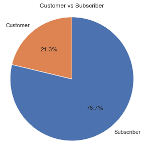

```python
# Proportion of the type of users in the Bay Wheels
user = df['user_type'].value_counts()/df.count()[0]
user

# Visualize the user type column
sb.set(rc={'figure.figsize':(14,5)})
plt.pie(user,labels=user.index, startangle=90, counterclock=False, autopct='%1.1f%%');
plt.axis('square')
plt.title('Customer vs Subscriber');
```

## Proportion of trips during the weekdays & weekends

```
max_week_order: 81410
max_prop: 0.15664806619203386
```

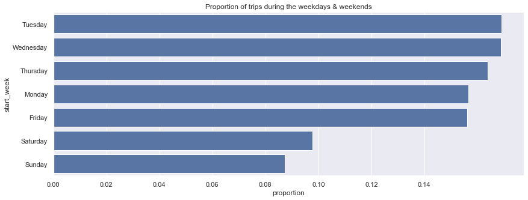

```python
# Proportion of users during the days of the week
week_counts = df['start_week'].value_counts()
week_order = week_counts.index
n_df = df.shape[0]
max_week_order = week_counts[0]
print('max_week_order:', max_week_order)
max_prop = max_week_order/n_df
print('max_prop:', max_prop)

tick_props = np.arange(0, max_prop, 0.02)
tick_names = ['{:0.2f}'.format(v) for v in tick_props]

# Visualize the number of rides on the days of the week
base_color = sb.color_palette()[0]
week_order = df['start_week'].value_counts().index
sb.countplot(data = df, y = 'start_week', color = base_color, order = week_order)
plt.xticks(tick_props * n_df, tick_names)
plt.xlabel('proportion')
plt.title('Proportion of trips during the weekdays & weekends');
```

# Most number of trips in a day

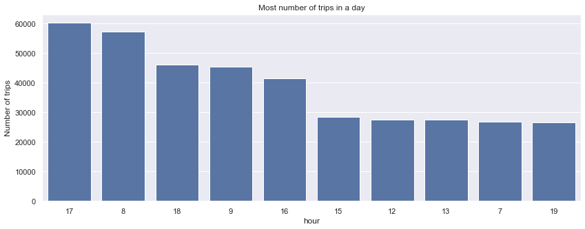

```python
hour_counts = df['hour'].value_counts().head(10)
hour_order = hour_counts.index
sb.countplot(data = df, x = 'hour', color = base_color, order = hour_order)
plt.xlabel('hour')
plt.ylabel('Number of trips')
plt.title('Most number of trips in a day');
```

We see that most of the trips are in the early morning at 8 hr followed by 9 hr and in the evenings at 17 hr and followed by 18 hr.We can say that the users are using the bikes for everyday transportation purposes during these hours of the day.

# Duration of the trips by the users

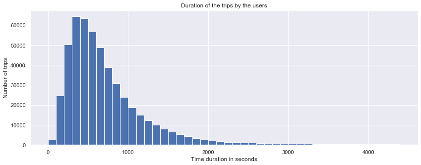

```python
bins = np.arange(0, 4500, 100)
plt.hist(data=df, x='duration_sec', bins=bins)
plt.xlabel('Time duration in seconds')
plt.ylabel('Number of trips')
plt.title('Duration of the trips by the users');
```

# Most trips per user type during the week

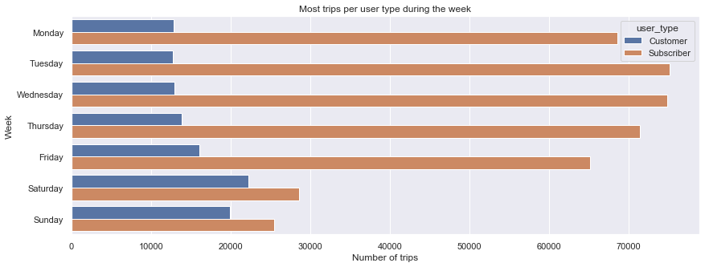

```python
# On which days and which type of user had the most rides
sb.countplot(data = df, y='start_week', hue = 'user_type')
plt.xlabel('Number of trips')
plt.ylabel('Week')
plt.title('Most trips per user type during the week');
```

1. We see that the subscriber users have most number of rides on the weekdays which implies that they are frequent riders during the weekdays where they have the advantages like discounts or flexibility which is more affordable on a daily basis.
2. The Customer users have the most rides on the weekends, which implies that they might use the vehicle for their leisure time.

# Trip Count Distribution by Hour

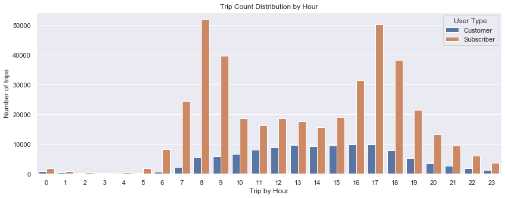

```python
sb.countplot(data=df, x='hour', hue='user_type')
plt.xlabel('Trip by Hour')
plt.ylabel('Number of trips')
plt.title('Trip Count Distribution by Hour')
plt.legend(title='User Type');
```

Wee see that highest number of trips are by subscribers and are most frequent during the morning between 8hr and 9 hr and in the evening between 17hr and 18hr. The trips by Customers is mostly between the afternoon and evening.

# Daily Trip Duration by User Type

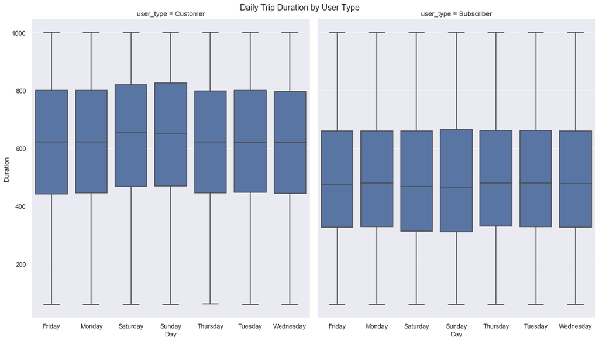

```python
# Lets take a bunch of data for easy visualizations. I have considered the trip duration less than or equal to around 16 minutes
duration_1000 = df.loc[df['duration_sec'] <= 1000]

g = sb.FacetGrid(data = duration_1000, col = 'user_type', height = 8.27, aspect = (14.70/2)/8.27)
g.map(sb.boxplot, 'start_week', 'duration_sec');
plt.suptitle("Daily Trip Duration by User Type", y = 1)
g.set_axis_labels('Day', 'Duration');
```

# Conclusion

1. From all the above visualizations we can conclude that being a subscriber for the Bay Wheels is more advantages compared to being a customer. There might be discounts, flexibility and also they are affordable if the subscription is made for frequent travel.
2. We see that the subscribers mostly use the bikes on weekdays for transporation purpose that is quiet quick to travel, whereas the customers use the bikes on weekends for their leisure or free time and also they have the bikes for a longer duration as compared to the subscribers.
3. The most frequent travel by subscribers is between 8 and 9 hr in the morning and between 17 and 18hr in the evening which implies that most of them use the bikes for work purpose or mobility on a daily basis which is easy to travel.
4. The most frequent travel time for customers is mostly between the afternoon and evenings.
5. So finally we can say that subscribers and the customers have two different behaviours.

```python
! jupyter nbconvert slide_deck.ipynb --to slides --post serve --template output_toggle
```

[output not shown]